# Surrounding Landscapes Report

Elizaveta Shcherbinina

2024-05-28

```r
# data packages
library(readr)
library(readxl)
library(tidyverse)
library(tidyr)
library(dplyr)
library(stringr)

# visualisation packages
library(ggplot2)
library(RColorBrewer)

# maps
library(maps)
library(sp)
```

# 0. Data Import

```r
# data import -------------------------------------------------------------

data <- read_csv("All_yield_coords_decimals_20240417 - Copy.csv",
                 col_types = cols(
                   Latitude = col_double(),   # some lat and long include characters or are missing in the csv file, so through setting them to double, we get NAs instead of them.
                   Longitude = col_double(),
                 ))

# because of the conversion to double, the dot in the column names was not read correctly, so here we fix it and delete the dot so it doesnt confuse R any further
data <- data %>%
    rename(`SiteRegion` = `Site/Region`,
         `Croptype` = `Crop type`)

data_pr <- #pr for processed. That will be the dataset we will be working with
    data %>%
    mutate(across(c(No., DatasetID, Country, SiteRegion, Croptype, yield_measure, Treatment, QualityOfDataPoint), as.factor),
         across(c(yield_control, yield_treatm), as.double))
```

```r
# we have 12 datasets, therefore 12 supplements/data sets

# 1.
D66_orig <- read_excel("primary_sources/Data_yield_coords/66-Liang2022_supp.xlsx")

# 2.
D309_orig_slow_releaze_fertilizer <- read_excel("primary_sources/Data_yield_coords/309-Ding2018_supp_5datasets.xlsx", sheet = 1)
D309_orig_slow_releaze_fertilizer$orig_Treatment <- "Slow Release Fertilizer"

D309_orig_organic_fertilizer <- read_excel("primary_sources/Data_yield_coords/309-Ding2018_supp_5datasets.xlsx", sheet = 2)
D309_orig_organic_fertilizer$orig_Treatment <- "Organic Fertilizer"

D309_orig_straw_return <- read_excel("primary_sources/Data_yield_coords/309-Ding2018_supp_5datasets.xlsx", sheet = 3)
D309_orig_straw_return$orig_Treatment <- "Straw Return"

D309_orig_green_manure <- read_excel("primary_sources/Data_yield_coords/309-Ding2018_supp_5datasets.xlsx", sheet = 4)
D309_orig_green_manure$orig_Treatment <- "Green Manure"

D309_orig_secondary_and_micronutrients <- read_excel("primary_sources/Data_yield_coords/309-Ding2018_supp_5datasets.xlsx", sheet = 5)
D309_orig_secondary_and_micronutrients$orig_Treatment <- "Secondary and Micronutrient Fertilizer"

D309_orig <- bind_rows(D309_orig_secondary_and_micronutrients, D309_orig_green_manure, D309_orig_straw_return, D309_orig_organic_fertilizer, D309_orig_slow_releaze_fertilizer ) # i followed the structure of the data_pr data base so that the observations are in the same order


# 3.
D331_orig <- read_excel("primary_sources/Data_yield_coords/331-Liu2023_supp.xlsx")

# 4.
D352_orig <- read_excel("primary_sources/Data_yield_coords/352-Zhang2021_supp2.xlsx")

# 5.
D473_orig <- read_excel("primary_sources/Data_yield_coords/473-Joshi2023_supp.xlsx")

# 6.
D652_orig <- read_excel("primary_sources/Data_yield_coords/652-Zheng2023_supp.xls")

# 7.
D669_orig <- read_excel("primary_sources/Data_yield_coords/669-Wang2023_suppA.xlsx")

# 8.
D906_orig <- read_excel("primary_sources/Data_yield_coords/906-Zhao2016_suppA.xlsx", skip = 1)

# 9A.
D921_A_orig <- read_excel("primary_sources/Data_yield_coords/921-Xia2023_suppA.xlsx")

# 9B.
D921_B_orig <- read_excel("primary_sources/Data_yield_coords/921-Xia2023_suppB.xlsx")

# 10.
D973_orig <- read_excel("primary_sources/Data_yield_coords/973-Wang2021_suppA.xlsx")

# 11.
D1120_orig <- read.csv("primary_sources/Data_yield_coords/1120-Steward2018_supp.csv")
```

# 1. Data Processing

- Already in the data import we created the processing dataset (data_pr, “pr” for “processed”), that is being modified. No changes are being made to the original dataset (data).  
  If an attrbute/column is being modified, a copy of this attribute is being  
  created “Croptype” to “pr_Croptype”, meaning that values within the processed  
  column were modified.

```r
data_pr %>%
  filter(No. == "5197")
```

| No. | DatasetID | Source | Country | SiteRegion | Latitude | Longitude | Croptype | yield_control | yield_treatm | yield_measure | Treatment | QualityOfDataPoint | Coordinate_format |
| --- | --- | --- | --- | --- | --- | --- | --- | --- | --- | --- | --- | --- | --- |
| 5197 | D973 | H��ppi et al., | Switzerland | Zurich | 47.41667 | 8.516667 | Upland arable land | 7.25 | 7.85 | Mg dry matter/ha | Straw addition | NA | Degr-Min-Sec |

```r
data_pr <-
data_pr %>%
  mutate(Source = ifelse(No. == "5197", "Hueppi et al., 2015", Source) )

data_pr %>%
  filter(No. == "5197")
```

| No. | DatasetID | Source | Country | SiteRegion | Latitude | Longitude | Croptype | yield_control | yield_treatm | yield_measure | Treatment | QualityOfDataPoint | Coordinate_format |
| --- | --- | --- | --- | --- | --- | --- | --- | --- | --- | --- | --- | --- | --- |
| 5197 | D973 | Hueppi et al., 2015 | Switzerland | Zurich | 47.41667 | 8.516667 | Upland arable land | 7.25 | 7.85 | Mg dry matter/ha | Straw addition | NA | Degr-Min-Sec |

1.1 We unify all the yield measure metrics to kg/ha.

```r
# 1.1 yield_measure unification -----------------------------------------------

data_pr <-
  data_pr %>%
  mutate(pr_yield_control_kgha = case_when(
    yield_measure == "Mg dry matter/ha" ~ yield_control * 10^6,
    yield_measure == "Mg/ha" ~ yield_control * 10^6,
    is.na(yield_measure) ~ 0, # set to zero temporarily due to metric uncertainty
    TRUE ~ yield_control # assume the rest are already in kg/ha
  )) %>%
  mutate(pr_yield_control_kgha = ifelse(pr_yield_control_kgha == 0, NA, pr_yield_control_kgha)) %>%
  mutate(pr_yield_treatm_kgha = case_when(
    yield_measure == "Mg dry matter/ha" ~ yield_treatm * 10^6,
    yield_measure == "Mg/ha" ~ yield_treatm * 10^6,
    is.na(yield_measure) ~ 0, # set to zero temporarily due to metric uncertainty
    TRUE ~ yield_treatm # assume the rest are already in kg/ha
  )) %>%
  mutate(pr_yield_treatm_kgha = ifelse(pr_yield_treatm_kgha == 0, NA, pr_yield_treatm_kgha)) %>%
  mutate(pr_yield_measure_unified = case_when(
    is.na(yield_measure) ~ NA_character_,
    TRUE ~ "kg/ha"
  ))
```

1.2 We create a “year” column for each observation

```r
# 1.2 Year column creation ----------------------------------------------------

data_pr$pr_pub_Year <- str_extract(data_pr$Source, "\\d{4}")

data_pr <-
data_pr %>%
  mutate(across(pr_pub_Year, as.numeric))

summary(data_pr$pr_pub_Year)
```

```
##    Min. 1st Qu.  Median    Mean 3rd Qu.    Max.    NA's
##    1973    2010    2013    2012    2016    2023    2499
```

There are 2500 NA values in the “pr_pub_Year”, meaning that 2500 years could not be extracted from the Source column. Look the “Working with the missing data” section.

```r
# 1.3 Croptype unification ----------------------------------------------------

# 1.3.1 Croptype unification
library(dplyr)
library(stringr)

data_pr <-
  data_pr %>%
  mutate(pr_Croptype = str_to_title(Croptype)) %>%
  mutate(pr_Croptype = case_when(
    grepl("ice", as.character(pr_Croptype)) ~ "Rice",
    grepl("Vegetable", as.character(pr_Croptype)) ~ "Vegetables",
    grepl("Corn", as.character(pr_Croptype)) ~ "Maize",
    pr_Croptype == "Greenhouse" ~ "Greenhouse_vegetable", # 1.3.2 addition of "_vegetable" to the "greenhouse" observation
    pr_Croptype == "Tubercrop" ~ "Vegetables",
    pr_Croptype == "Soybeans" ~ "Vegetables",
    TRUE ~ as.character(pr_Croptype)
  )) %>%
  mutate(pr_Croptype = as.factor(pr_Croptype))
```

```r
#  1.4 Longitude and Latitude repair  --------------------------------------------

data_pr <-
  data_pr %>%
  mutate(
    pr_Longitude = Longitude,
    pr_Latitude = Latitude
  )

# 1.4.1 Swap Longitude and Latitude for the selected section: Latitude > 90
condition <- data_pr$Latitude > 90

data_pr <-
  data_pr %>%
  mutate(
    temp = ifelse(condition, pr_Longitude, NA_real_),  # Temporarily store Longitude in temp
    pr_Longitude = ifelse(condition, pr_Latitude, pr_Longitude),  # Replace Longitude with Latitude
    pr_Latitude = ifelse(condition, temp, pr_Latitude)  # Replace Latitude with temp
  ) %>%
  select(-temp)  # Remove the temporary column

# 1.4.2 Swap Longitude and Latitude for the selected section: Latitude < -90
condition2 <- data_pr$Latitude < -90

data_pr <-
  data_pr %>%
  mutate(
    temp = ifelse(condition2, pr_Longitude, NA_real_),  # Temporarily store Longitude in temp
    pr_Longitude = ifelse(condition2, pr_Latitude, pr_Longitude),  # Replace Longitude with Latitude
    pr_Latitude = ifelse(condition2, temp, pr_Latitude)  # Replace Latitude with temp
  ) %>%
  select(-temp)  # Remove the temporary column

# 1.4.3 Correct the Marrabel coordinates, because the minus is in the wrong column

condition3 <- data_pr$SiteRegion %in% c("Marrabel")

data_pr <-
  data_pr %>%
  mutate(
    pr_Longitude = ifelse(condition3, -pr_Longitude, pr_Longitude),  # Replace Longitude with Latitude
    pr_Latitude = ifelse(condition3, -pr_Latitude, pr_Latitude)  # Replace Latitude with temp
  )


# 1.4.4 Set wrong coordinates to NA
condition4 <- data_pr$pr_Longitude > 10000

data_pr <-
  data_pr%>%
    mutate(pr_Longitude = ifelse(condition4, NA_character_, pr_Longitude),
           pr_Latitude = ifelse(condition4, NA_character_, pr_Latitude))
```

The dataset D973 got assfigned “straw addition” by mistake. The paper was investigating the effect of Liming.

```r
# 1.5 Treatment correction D973 --------------------------------------------------------

data_pr <-
data_pr %>%
  mutate(pr_Treatment = ifelse(DatasetID == "D973", "Liming", as.character(Treatment)))
```

A similar case happened to the D309, where all observations got assigned to the “straw addition”, whereas five different treatments were investigated. The code junk for correction can be found later in the 2. Working with the missing data section by 2.3

# 2. Working on the missing data

```r
# 2.1 Croptpe 1 NA --------------------------------------------------------

data_pr %>%
  filter(Croptype %in% c(NA_character_)) %>%
  select(No. , Source, DatasetID)
```

| No. | Source | DatasetID |
| --- | --- | --- |
| 3744 | Zhang et al. (2021) | D669 |

```r
data_pr <-
data_pr %>%
  mutate(pr_Croptype = ifelse(No. == "3744", "Greenhouse_vegetable", as.character(pr_Croptype)))
```

@Elizaveta: This observation is also missing in the original primary supplement.  
Might be a typo, because all other observations from the same primary publication  
(the one used in the primary dataset as an observation), have the croptype  
“Greenhouse” assigned. In the meeting in the 28/5/24 we agreed on assigning  
the “greenhouse” value to this observation.

```r
# 2.2 working on the unknown YEAR problem ---------------------------------------

table_missing_years <-
data_pr %>%
  filter(pr_pub_Year %in% c(NA_character_)) %>%
  group_by(DatasetID) %>%
  summarise(Occurrences = n())

knitr::kable(table_missing_years, caption = "Datasets with missing years")
```

Datasets with missing years

| DatasetID | Occurrences |
| --- | --- |
| D331 | 475 |
| D473 | 198 |
| D652 | 1503 |
| D66 | 315 |
| D669 | 3 |
| D921B | 5 |

**D331**: 475 observations only have a title of the paper with no further citation. Those titles were looked up on the CNKI (Chineese Database Web) and the publication dates were recorded. **!! Important Note:** Some observations are no *real* publications, but master thesises. On the CNKI the have a publication type “Master Thesis”. **D473**: Has a StudyID in the Source column, therefore the Year could not be extracted. However, has a “Year” column, that can be joined. **652**: Has a StudyID in the Source column, therefore the Year could not be extracted. The actual references can be found in the word supplement. **D66**: Has a StudyID in the Source column, and no further references in the supplementary information.  
**D669**: The study of Le et al. could not be foung neither in Google Scholar nor in CNKI  
**D921B, D973**: correct the typos

```r
# D331 filling the missing Year values --------

D331_years <- read.csv("d331_years.csv")
D331_years <-
  D331_years %>%
  select(Source, Publication_Date) %>%
  unique()

D331_years <-
D331_years %>%
  mutate(pr_pub_Year = str_extract(D331_years$Publication_Date, "\\d{4}"))


D331_years <-
  D331_years %>%
  mutate(across(pr_pub_Year, as.numeric))


data_pr <-
  left_join(data_pr, D331_years, join_by("Source"=="Source"), relationship = "many-to-one",
            suffix = c(".data_pr", ".D331"))

data_pr <-
  data_pr %>%
  mutate(pr_pub_Year.data_pr = case_when(
    pr_pub_Year.D331 %in% c(NA_character_) ~ pr_pub_Year.data_pr,
    TRUE ~ pr_pub_Year.D331
  ))


data_pr <-
 data_pr %>%
   rename_at('pr_pub_Year.data_pr', ~'pr_pub_Year') %>%
   select(-pr_pub_Year.D331, -Publication_Date)
```

```r
# D473 filling the missing Year values --------

D473_years <-
  D473_orig %>%
  select(Study_ID, Year) %>%
  unique() %>%
  mutate(Study_ID = paste0("D473", sep = "_", as.character(Study_ID)))

data_pr <-
data_pr %>%
  mutate(pr_StudyID = paste0(DatasetID, sep = "_", Source))

data_pr <-
  left_join(data_pr, D473_years, join_by("pr_StudyID"=="Study_ID"), relationship = "many-to-one")


data_pr <-
  data_pr %>%
  mutate(pr_pub_Year = ifelse(DatasetID == "D473", Year, pr_pub_Year))


data_pr <-
 data_pr %>%
   select(-Year)
```

```r
# D652 filling the missing Year values --------


D652_years <- read.csv("d652_years.csv", header = FALSE)

D652_years <-
D652_years %>%
    rename(`DatasetID` = `V1`,
         `StudyNr` = `V2`,
         `Source` = `V3`) %>%
  select(-V4)

D652_years <-
D652_years %>%
  mutate(Year = str_extract(D652_years$Source, "\\b(19[6-9][0-9]|20[0-1][0-9]|2020|2021|2022)\\b") # in this case the Year extraction is kind of awkward because the source utilized different citation styles, and I cannot extract just the 4 digits or define the surroundings.
         ) %>%
  mutate(StudyID = paste0("D652", sep = "_", as.character(StudyNr))) %>%
  select(StudyID, Year) %>%
  unique()  %>%
  mutate(across(Year, as.numeric))


data_pr <-
  left_join(data_pr, D652_years, join_by("pr_StudyID"=="StudyID"), relationship = "many-to-one")


data_pr <-
  data_pr %>%
  mutate(pr_pub_Year = ifelse(DatasetID == "D652", Year, pr_pub_Year)) %>%
  select(-Year)
```

```r
# D921B correcting the typos --------

data_pr %>%
  filter(pr_pub_Year %in% c(NA_character_),
         DatasetID == "D921B")
```

| No. | DatasetID | Source | Country | SiteRegion | Latitude | Longitude | Croptype | yield_control | yield_treatm | yield_measure | Treatment | QualityOfDataPoint | Coordinate_format | pr_yield_control_kgha | pr_yield_treatm_kgha | pr_yield_measure_unified | pr_pub_Year | pr_Croptype | pr_Longitude | pr_Latitude | pr_Treatment | pr_StudyID |
| --- | --- | --- | --- | --- | --- | --- | --- | --- | --- | --- | --- | --- | --- | --- | --- | --- | --- | --- | --- | --- | --- | --- |
| 5052 | D921B | Liu et al., 201 | NA | NA | 41.19 | 121.380 | Corn | 10333 | 10914 | kg/ha | Straw addition | Not sure about control-treatment columns | Decimal | 10333 | 10914 | kg/ha | NA | Maize | 121.38 | 41.19 | Straw addition | D921B_Liu et al., 201 |
| 5067 | D921B | Bahrani et al., 207 | NA | NA | 52.77 | 29.833 | Corn | 13800 | 16400 | kg/ha | Straw addition | Not sure about control-treatment columns | Decimal | 13800 | 16400 | kg/ha | NA | Maize | 29.833 | 52.77 | Straw addition | D921B_Bahrani et al., 207 |
| 5068 | D921B | Bahrani et al., 207 | NA | NA | 52.77 | 29.833 | Corn | 13800 | 15400 | kg/ha | Straw addition | Not sure about control-treatment columns | Decimal | 13800 | 15400 | kg/ha | NA | Maize | 29.833 | 52.77 | Straw addition | D921B_Bahrani et al., 207 |
| 5069 | D921B | Bahrani et al., 207 | NA | NA | 52.77 | 29.833 | Corn | 13800 | 12600 | kg/ha | Straw addition | Not sure about control-treatment columns | Decimal | 13800 | 12600 | kg/ha | NA | Maize | 29.833 | 52.77 | Straw addition | D921B_Bahrani et al., 207 |
| 5070 | D921B | Bahrani et al., 207 | NA | NA | 52.77 | 29.833 | Corn | 13800 | 10300 | kg/ha | Straw addition | Not sure about control-treatment columns | Decimal | 13800 | 10300 | kg/ha | NA | Maize | 29.833 | 52.77 | Straw addition | D921B_Bahrani et al., 207 |

```r
condition5 <-  data_pr$pr_pub_Year%in% c(NA_character_) &  data_pr$Source == "Bahrani et al., 207"

data_pr <-
data_pr %>%
  mutate(Source = ifelse(condition5, "Bahrani et al., 2007", Source),
         pr_pub_Year = ifelse(condition5, 2007, pr_pub_Year))

# check:
data_pr %>%
  filter(pr_pub_Year %in% c(NA_character_),
         DatasetID == "D921B")
```

| No. | DatasetID | Source | Country | SiteRegion | Latitude | Longitude | Croptype | yield_control | yield_treatm | yield_measure | Treatment | QualityOfDataPoint | Coordinate_format | pr_yield_control_kgha | pr_yield_treatm_kgha | pr_yield_measure_unified | pr_pub_Year | pr_Croptype | pr_Longitude | pr_Latitude | pr_Treatment | pr_StudyID |
| --- | --- | --- | --- | --- | --- | --- | --- | --- | --- | --- | --- | --- | --- | --- | --- | --- | --- | --- | --- | --- | --- | --- |
| 5052 | D921B | Liu et al., 201 | NA | NA | 41.19 | 121.38 | Corn | 10333 | 10914 | kg/ha | Straw addition | Not sure about control-treatment columns | Decimal | 10333 | 10914 | kg/ha | NA | Maize | 121.38 | 41.19 | Straw addition | D921B_Liu et al., 201 |

Bahrani et al: Bahrani M., Raufat M., Ghadiri H., 2007. Influence of wheat residue management on irrigated corn grain production in a reduced tillage system. Soil & Tillage Research, 94, 305-309.  
So, the year can be changed to 2007.  
However, there are too many different papers from “Liu” , so the year could not be identified.

```r
summary(data_pr$pr_pub_Year)
```

```
##    Min. 1st Qu.  Median    Mean 3rd Qu.    Max.    NA's
##    1973    2010    2014    2013    2017    2023     378
```

**Important Remark**:  
Sometimes a dataset has a “Year” column. Those years can be publication years or harvest years. I will import those in the harvest_Year column, because the difference between the harvest and the publication is sometimes longer than 10 years. Datasets that have a harvest year column: D973, D1120, D906

```r
#  D973 add harvest year ----------------------

D973_orig <-
D973_orig %>%
  mutate(Citation = ifelse(NO. == "2", "Hueppi et al., 2015", Citation) )

D973_years <-
D973_orig %>%
  select(Citation, Year, `Crop yield`, ...35) %>%
  drop_na() %>%
  unique()  %>%
  mutate(Year = str_extract(Year, "\\d{4}")) %>%
  mutate(across(c(`Crop yield`, ...35), as.numeric))

D973_years$`Crop yield` <-  round(D973_years$`Crop yield`, digits = 2)
D973_years$...35 <-  round(D973_years$...35, digits = 2)

D973_years <-
  D973_years %>%
  mutate(pr_Source_yield = paste0(Citation, sep = "_", as.character(`Crop yield`), sep = "_", as.character(...35))) %>%
  select(pr_Source_yield, Year) %>%
  distinct(pr_Source_yield, .keep_all = TRUE)

data_pr <-
data_pr %>%
  mutate(pr_Source_yield = paste0(Source, sep = "_", as.character(yield_control), sep = "_", as.character(yield_treatm)))

data_pr <-
  left_join(data_pr, D973_years, join_by("pr_Source_yield"=="pr_Source_yield"), relationship = "many-to-one")

data_pr <-
  data_pr %>%
  mutate(pr_harvest_Year = Year) %>%
  select(-Year)
```

```r
# D1120 add the harvest year --------------

D1120_years <-
  D1120_orig %>%
  mutate(harvest_Year = str_extract(HarvestE, "\\d{4}")) %>%
  mutate(author_yield = paste0(Author, sep = "_", as.character(YieldCT), sep = "_", as.character(YieldNT))) %>%
  select(author_yield, harvest_Year) %>%
  drop_na() %>%
  unique()

data_pr  <-
data_pr %>%
  mutate(pr_first_author = str_extract(Source, "^[^ et]+"),
         pr_author_yield = paste0(pr_first_author, sep = "_", as.character(yield_control), sep = "_", as.character(yield_treatm)))

data_pr <-
  left_join(data_pr, D1120_years, join_by("pr_author_yield"=="author_yield"), relationship = "many-to-one") %>%
  mutate(pr_harvest_Year = ifelse(DatasetID == "D1120", harvest_Year, pr_harvest_Year)) %>%
  select(-harvest_Year, -pr_first_author, -pr_author_yield)
```

```r
# D906 add the harvest year --------------

# since both datasets have dublicates, it will be hard to join them based on a relationship.
# therefore, i check whether the order of the obsns in both data sets is the same.

D906_temp <-
  D906_orig %>%
  slice(1:381) %>%
  select(Ref., Year, `Maize yield (Mg/ha)`) %>%
  mutate(pr_Source_yield = paste0(Ref., sep = "_", as.character(`Maize yield (Mg/ha)`), sep = "_", as.character(NA_character_))) %>%
  select(pr_Source_yield)

data_pr_temp <-
data_pr %>%
  filter(DatasetID == "D906") %>%
  select(pr_Source_yield)

map2_lgl(
  D906_temp, data_pr_temp,
  ~ all(.x == .y)
)
```

```
## pr_Source_yield
##            TRUE
```

```r
# The result is TRUE, so we can just merge this two datasets based on the rownumber
rm(D906_temp)
rm(data_pr_temp)

temp <-
data_pr %>%
  filter(DatasetID == "D906") %>%
  select(No.)


D906_years <-
  D906_orig %>%
  slice(1:381) %>%
  select(Ref., Year, `Maize yield (Mg/ha)`) %>%
  mutate(pr_Source_yield = paste0(Ref., sep = "_", as.character(`Maize yield (Mg/ha)`), sep = "_", as.character(NA_character_))) %>%
  select(Year) %>%
  mutate(No. = temp$No.)



data_pr <-
  left_join(data_pr, D906_years, join_by("No."=="No."))   %>%
  mutate(pr_harvest_Year = ifelse(DatasetID == "D906", Year, pr_harvest_Year)) %>%
  select(-Year)

data_pr <-
data_pr %>%
  mutate(across(pr_harvest_Year, as.numeric))
```

```r
summary(data_pr$pr_harvest_Year)
```

```
##    Min. 1st Qu.  Median    Mean 3rd Qu.    Max.    NA's
##    1962    1990    1997    1996    2006    2017    7771
```

```r
# 2.3 Treatment correction D309 --------------------------------------------------------

# D309_orig follows the same order of observations as the data_pr

temp <-
data_pr %>%
  filter(DatasetID == "D309") %>%
  select(No.)

D309_treatment <-
  D309_orig %>%
  select(orig_Treatment) %>%
  mutate(No. = temp$No.)


data_pr <-
  left_join(data_pr, D309_treatment, join_by("No."=="No."))   %>%
  mutate(pr_Treatment = ifelse(DatasetID == "D309", orig_Treatment, pr_Treatment)) %>%
  select(-orig_Treatment)
```

# 3. preparing the data set for the land cover mapping

```r
data_pr <-
data_pr %>%
  mutate(pr_Year_difference = pr_pub_Year - pr_harvest_Year)

summary(data_pr$pr_Year_difference)
```

```
##    Min. 1st Qu.  Median    Mean 3rd Qu.    Max.    NA's
##    1.00    4.00    7.00   10.57   11.00   57.00    7771
```

The median of the difference between the harvest and the publication is 7 years. The mean, however, is 10.5 yrs. We decided to use the median value.

```r
data_pr <-
data_pr %>%
  mutate(pr_harvest_Year_by_median = pr_pub_Year-7)

summary(data_pr$pr_harvest_Year_by_median)
```

```
##    Min. 1st Qu.  Median    Mean 3rd Qu.    Max.    NA's
##    1966    2003    2007    2006    2010    2016     378
```

also, we do not need any points with either no coordinates or no year indications:

```r
data_pr <-
data_pr %>%
  filter(!(pr_pub_Year %in% NA_character_)) %>%
  filter(!(pr_Longitude %in% NA_character_)) %>%
   filter(!(pr_Latitude %in% NA_character_))
```

The land cover map found in the gee has the year 1985, 1990, 1995, 2000-2022 (yearly). Let’s assign the land coiver map year:

```r
data_pr <- data_pr %>%
  mutate(pr_land_cover_Year = case_when(
    pr_harvest_Year_by_median >= 2000 & pr_harvest_Year_by_median <= 2022 ~ pr_harvest_Year_by_median,
    pr_harvest_Year_by_median < 1975 ~ NA_integer_,
    pr_harvest_Year_by_median >= 1975 & pr_harvest_Year_by_median <= 1987 ~ 1985,
    pr_harvest_Year_by_median >= 1988 & pr_harvest_Year_by_median <= 1992 ~ 1990,
    pr_harvest_Year_by_median >= 1993 & pr_harvest_Year_by_median <= 1997 ~ 1995,
    pr_harvest_Year_by_median > 1997 & pr_harvest_Year_by_median <= 2000 ~ 2000,
    TRUE ~ NA_integer_  # default case if none of the above conditions match
  ))
```

```r
data_pr_final_wide <-
data_pr %>%
  select(No., DatasetID, Country, SiteRegion, QualityOfDataPoint, Coordinate_format, pr_yield_control_kgha, pr_yield_treatm_kgha, pr_Croptype, pr_Treatment, pr_Longitude, pr_Latitude, pr_harvest_Year_by_median, pr_land_cover_Year )

write.csv(data_pr_final_wide, "points_wide.csv", row.names = FALSE)
```

```r
data_pr_final_long <-
data_pr_final_wide %>%
  pivot_longer(cols=c('pr_yield_control_kgha', 'pr_yield_treatm_kgha'),
                    names_to='pr_yield_type',
                    values_to='pr_yield_kgha') %>%
  mutate(pr_yield_type = case_when(
    pr_yield_type == "pr_yield_control_kgha" ~ "control",
    pr_yield_type == "pr_yield_treatm_kgha" ~ "treatment",
  )) %>%
  mutate(pr_Treatment = case_when(
    pr_yield_type == "control" ~ "Control"
  ))

#write.csv(data_pr_final_long, "data_pr_final.csv", row.names = FALSE)
```

```r
write.csv(data_pr_final_wide, "points.csv", row.names = FALSE)


# UNCOMMENT THE FOLLWOING IF YOU NEED SEPARATE DATASETS ---------------------



# dir.create(file.path(dirname("C:\\Users\\lisa7\\Documents\\surrounding_landscapes\\points"), "points"))
#
# data_points_1985 <-
# data_pr_final_wide %>%
#   filter(pr_land_cover_Year == "1985")
# write.csv(data_points_1985,
#           file.path("C:\\Users\\lisa7\\Documents\\surrounding_landscapes\\points\\", "points_1985.csv"),
#           row.names = FALSE)
#
# data_points_1990 <-
# data_pr_final_wide %>%
#   filter(pr_land_cover_Year == "1990")
# write.csv(data_points_1990,
#           file.path("C:\\Users\\lisa7\\Documents\\surrounding_landscapes\\points", "points_1990.csv"),
#           row.names = FALSE)
#
# data_points_1995 <-
# data_pr_final_wide %>%
#   filter(pr_land_cover_Year == "1995")
# write.csv(data_points_1995,
#           file.path("C:\\Users\\lisa7\\Documents\\surrounding_landscapes\\points", "points_1995.csv"),
#           row.names = FALSE)
#
# years <- seq(2000,2022)
#
# data_points_1995 <-
# data_pr_final_wide %>%
#   filter(pr_land_cover_Year == "1995")
# write.csv(data_points_1995,
#           file.path("C:\\Users\\lisa7\\Documents\\surrounding_landscapes\\points", "points_1995.csv"),
#           row.names = FALSE)
#
#
#
# for (i in years) {
# data <-
# data_pr_final_wide %>%
#   filter(pr_land_cover_Year == i)
#
# write.csv(data, file.path("C:\\Users\\lisa7\\Documents\\surrounding_landscapes\\points",
#                           paste0("points", sep = "_", as.character(i), ".csv")),
#                           row.names = FALSE)
# }
```

Result: we went from 2500 NAs to 378.

### S.1 What is the difference between harvest and publication

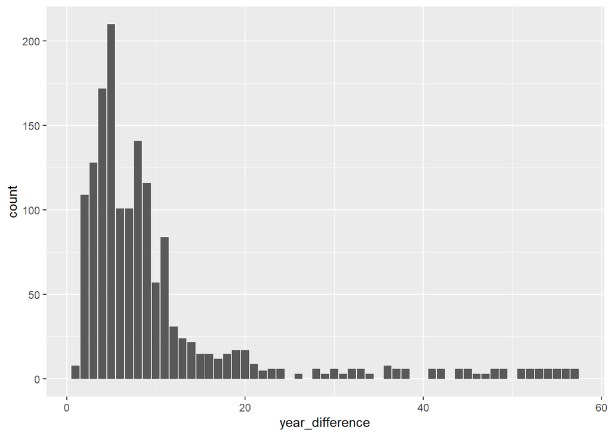

```r
data_pr %>%
  mutate(year_difference = pr_pub_Year - pr_harvest_Year) %>%
  ggplot(aes(x = year_difference)) +
  geom_bar() #+
```

```r
  scale_x_continuous(breaks = seq(min(0),
                                  max(70),
                                  by = 5))
```

```
## <ScaleContinuousPosition>
##  Range:
##  Limits:    0 --    1
```